# Task_4_1

Johannes Schwietering

2024-05-05

## Load Data

```r
# Load the diabetes dataset
heart_data <- read.csv("heartdata.csv")

# View the first few rows of the dataset
head(heart_data)
```

```
##   X    biking   smoking heartdisease
## 1 1 30.801246 10.896608    11.769423
## 2 2 65.129215  2.219563     2.854081
## 3 3  1.959665 17.588331    17.177803
## 4 4 44.800196  2.802559     6.816647
## 5 5 69.428454 15.974505     4.062224
## 6 6 54.403626 29.333176     9.550046
```

```r
str(heart_data)
```

```
## 'data.frame':    498 obs. of  4 variables:
##  $ X           : int  1 2 3 4 5 6 7 8 9 10 ...
##  $ biking      : num  30.8 65.13 1.96 44.8 69.43 ...
##  $ smoking     : num  10.9 2.22 17.59 2.8 15.97 ...
##  $ heartdisease: num  11.77 2.85 17.18 6.82 4.06 ...
```

Data looks good, lets continue

## Check Assumptions

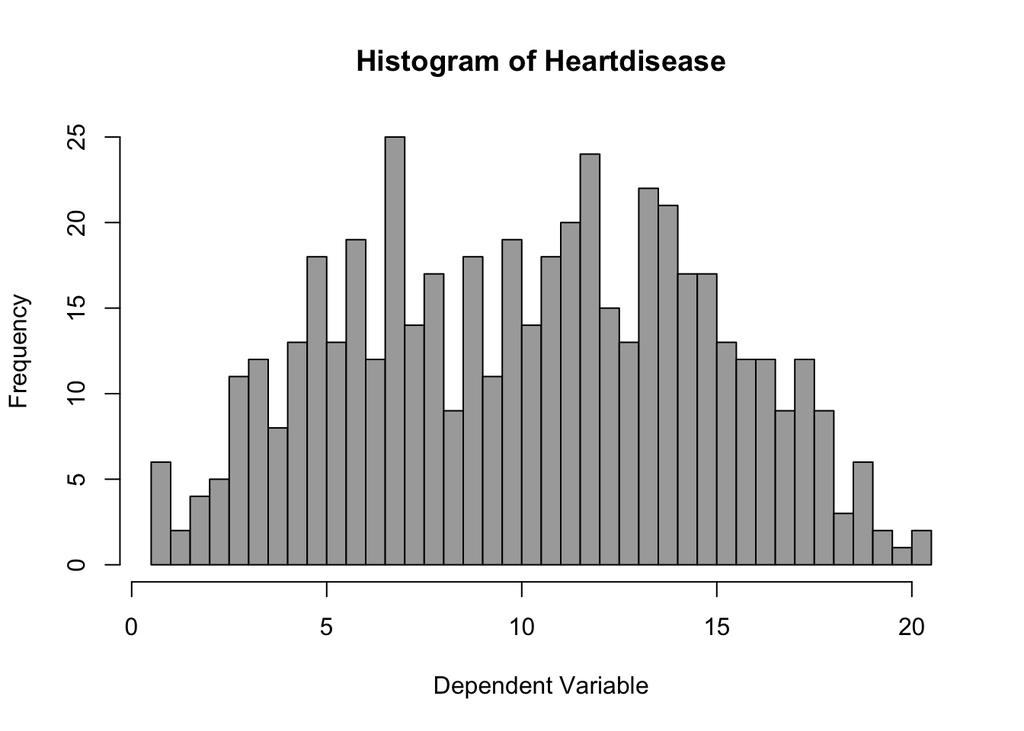

```r
# Assuming 'heart_data' is already loaded in your R environment

# Assumption 1: Independence of observations
# Note: Typically checked by understanding the data collection process or using time-series analysis techniques
# Not applicable here directly because we assume one observation per subject with no time component

# Assumption 2: Normality of the dependent variable
hist(heart_data$heartdisease, main = "Histogram of Heartdisease",
     xlab = "Dependent Variable", breaks = 30, col = "darkgray")
```

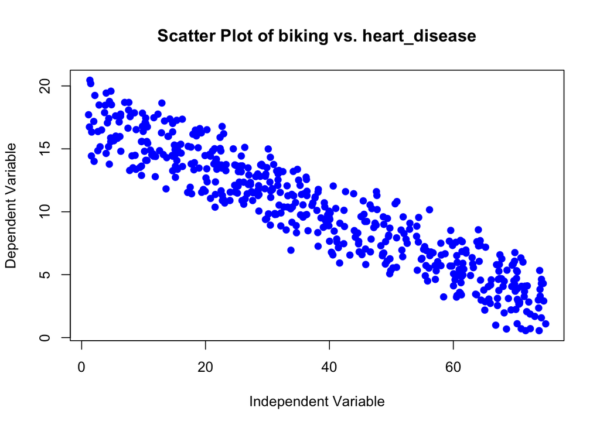

```r
# Assumption 3: Linearity
plot(heart_data$biking, heart_data$heartdisease,
     main = "Scatter Plot of biking vs. heart_disease",
     xlab = "Independent Variable", ylab = "Dependent Variable",
     pch = 19, col = "blue")  # pch = 19 makes the points solid, col = "blue" colors them blue
```

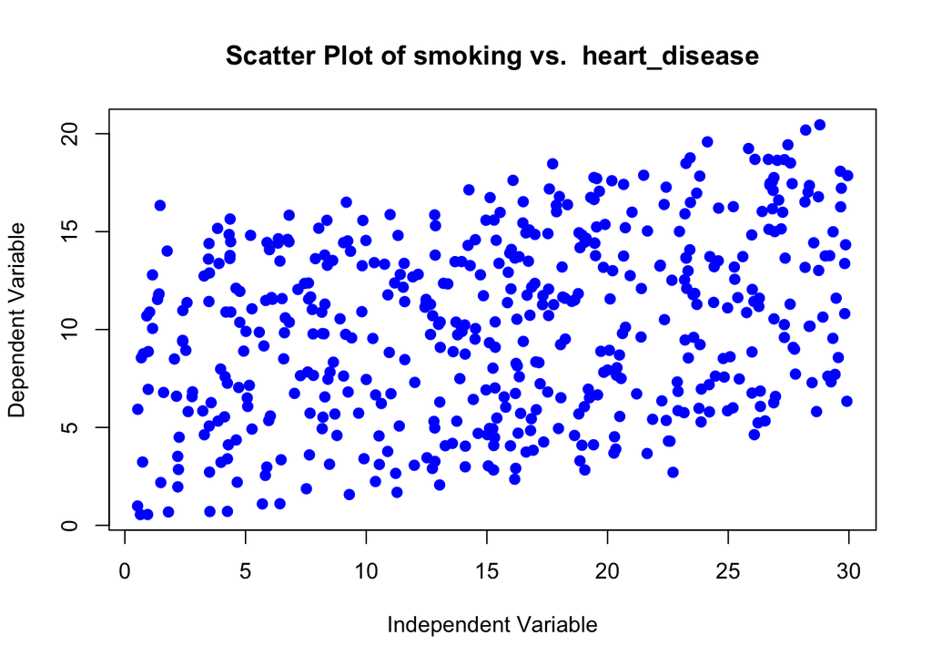

```r
plot(heart_data$smoking, heart_data$heartdisease,
     main = "Scatter Plot of smoking vs.  heart_disease",
     xlab = "Independent Variable", ylab = "Dependent Variable",
     pch = 19, col = "blue")  # pch = 19 makes the points solid, col = "blue" colors them blue
```

Interpretation Biking vs heart disease: There is a noticeable downward trend suggesting that increased biking activity is associated with a lower occurrence or severity of heart disease, although the spread of data points indicates that individual responses may vary.

Interpretation Smoking vs. heart disease: There appears to be a generally increasing trend, suggesting that as smoking increases, the incidence or severity of heart disease also tends to increase, though the dispersion of points indicates considerable variability in this relationship.

## Linear model

```r
# Fit a linear model
model1 <- lm(heartdisease ~ biking, data = heart_data)
model2 <- lm(heartdisease ~ smoking, data = heart_data)
model3 <- lm(heartdisease ~ biking + smoking, data=heart_data)

summary(model1)
```

```
##
## Call:
## lm(formula = heartdisease ~ biking, data = heart_data)
##
## Residuals:
##    Min     1Q Median     3Q    Max
## -4.028 -1.206 -0.004  1.151  3.643
##
## Coefficients:
##              Estimate Std. Error t value Pr(>|t|)
## (Intercept) 17.697884   0.146780  120.57   <2e-16 ***
## biking      -0.199091   0.003378  -58.94   <2e-16 ***
## ---
## Signif. codes:  0 '***' 0.001 '**' 0.01 '*' 0.05 '.' 0.1 ' ' 1
##
## Residual standard error: 1.618 on 496 degrees of freedom
## Multiple R-squared:  0.8751, Adjusted R-squared:  0.8748
## F-statistic:  3474 on 1 and 496 DF,  p-value: < 2.2e-16
```

```r
summary(model2)
```

```
##
## Call:
## lm(formula = heartdisease ~ smoking, data = heart_data)
##
## Residuals:
##     Min      1Q  Median      3Q     Max
## -8.7065 -3.7069  0.5007  3.6597  8.5434
##
## Coefficients:
##             Estimate Std. Error t value Pr(>|t|)
## (Intercept)  7.54311    0.41251  18.286  < 2e-16 ***
## smoking      0.17048    0.02355   7.239 1.73e-12 ***
## ---
## Signif. codes:  0 '***' 0.001 '**' 0.01 '*' 0.05 '.' 0.1 ' ' 1
##
## Residual standard error: 4.352 on 496 degrees of freedom
## Multiple R-squared:  0.09556,    Adjusted R-squared:  0.09374
## F-statistic: 52.41 on 1 and 496 DF,  p-value: 1.729e-12
```

```r
summary(model3)
```

```
##
## Call:
## lm(formula = heartdisease ~ biking + smoking, data = heart_data)
##
## Residuals:
##     Min      1Q  Median      3Q     Max
## -2.1789 -0.4463  0.0362  0.4422  1.9331
##
## Coefficients:
##              Estimate Std. Error t value Pr(>|t|)
## (Intercept) 14.984658   0.080137  186.99   <2e-16 ***
## biking      -0.200133   0.001366 -146.53   <2e-16 ***
## smoking      0.178334   0.003539   50.39   <2e-16 ***
## ---
## Signif. codes:  0 '***' 0.001 '**' 0.01 '*' 0.05 '.' 0.1 ' ' 1
##
## Residual standard error: 0.654 on 495 degrees of freedom
## Multiple R-squared:  0.9796, Adjusted R-squared:  0.9795
## F-statistic: 1.19e+04 on 2 and 495 DF,  p-value: < 2.2e-16
```

Model 1, focused solely on biking, shows a strong inverse relationship between biking and heart disease severity, with a substantial 87.51% of the variance in heart disease explained by biking, indicated by a high R-squared value. Model 2 examines smoking and shows a positive correlation, though it only explains about 9.56% of the variance in heart disease, suggesting a weaker but significant impact of smoking. Model 3 combines both biking and smoking and demonstrates an even stronger model fit, with an R-squared of 97.96%, indicating that together, these factors provide a highly predictive model of heart disease severity. This model robustly supports the protective effect of biking against heart disease and the detrimental impact of smoking, while providing a highly precise estimate of heart disease severity based on these variables.

## Homoscedasticity

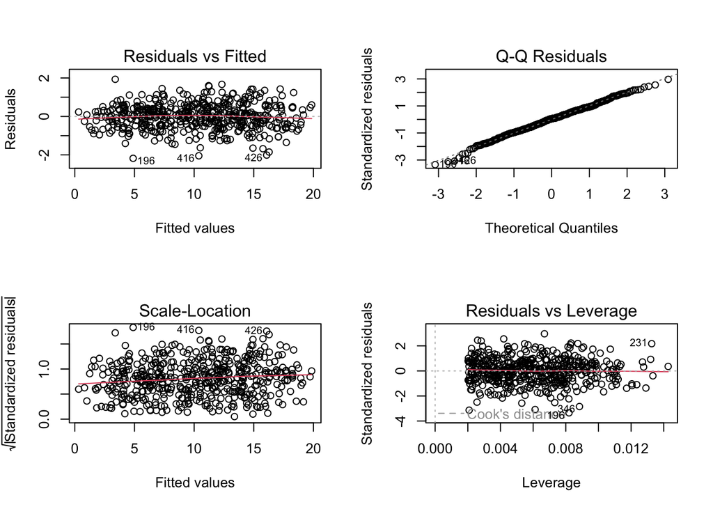

```r
par(mfrow=c(2,2))
plot(model3)
```

The “Residuals vs Fitted” plot does not show any obvious pattern or systematic curvature, indicating that the linearity assumption holds well. The “Q-Q Plot” of the standardized residuals indicates that the residuals are approximately normally distributed, as evidenced by the residuals following closely along the diagonal line. The “Scale-Location” plot shows some variation in spread along the range of fitted values but is relatively stable, suggesting only mild concerns regarding heteroscedasticity. Lastly, the “Residuals vs Leverage” plot shows no points with high leverage that have a significant influence on the model, indicating that there are no particularly influential outliers affecting the model fit. Overall, the model appears well-specified with minor concerns related to equal variance of residuals across the range of predictions.

## Train the Model

```r
fitControl <- trainControl(##10-fold CV
            method = "cv",
            number = 10)
lmFit <- train(heartdisease ~ ., data=heart_data, preProcess=c("center", "scale"), method="lm", trControl=fitControl)

print(lmFit)
```

```
## Linear Regression
##
## 498 samples
##   3 predictor
##
## Pre-processing: centered (3), scaled (3)
## Resampling: Cross-Validated (10 fold)
## Summary of sample sizes: 448, 450, 447, 448, 447, 449, ...
## Resampling results:
##
##   RMSE       Rsquared   MAE
##   0.6517509  0.9800983  0.5174621
##
## Tuning parameter 'intercept' was held constant at a value of TRUE
```

```r
summary(lmFit)
```

```
##
## Call:
## lm(formula = .outcome ~ ., data = dat)
##
## Residuals:
##      Min       1Q   Median       3Q      Max
## -2.21379 -0.44156  0.01871  0.44130  1.95468
##
## Coefficients:
##             Estimate Std. Error  t value Pr(>|t|)
## (Intercept) 10.17454    0.02917  348.771   <2e-16 ***
## X           -0.06934    0.02929   -2.367   0.0183 *
## biking      -4.29526    0.02925 -146.838   <2e-16 ***
## smoking      1.48197    0.02924   50.675   <2e-16 ***
## ---
## Signif. codes:  0 '***' 0.001 '**' 0.01 '*' 0.05 '.' 0.1 ' ' 1
##
## Residual standard error: 0.651 on 494 degrees of freedom
## Multiple R-squared:  0.9798, Adjusted R-squared:  0.9797
## F-statistic:  8006 on 3 and 494 DF,  p-value: < 2.2e-16
```

The model fitting was conducted using 10-fold cross-validation, which partitions the data into 10 subsets, using each in turn for validation while training on the remaining subsets. This approach helps in estimating the model’s prediction accuracy more robustly by averaging the results across different subsets.